# Be Curious Results

Leeds Clinical Trials Research Unit

07/05/2022

We hope you enjoyed taking part in our chocolate egg clinical trial at Be Curious! Here are the results from our trial.

### Overall summary

- We had 130 participants take part in our Chocolate trial at Be Curious. 61 were given white chocolate and 69 were given milk chocolate.
- Only 2 participants were not happy after eating their chocolate!
- We saw no difference in happiness between the two chocolate groups. This means chocolate makes people happy, no matter what!

### Graph summaries (suitable for 5+ years old)

This is a bar chart. It shows us all the information from the different people we surveyed at Be Curious this year. The chart can give us an early idea on whether there might be a link between the chocolate groups and the different levels of happiness.

Do you think there might be a link? Is everyone very happy? Are more people happy after eating white chocolate or milk chocolate? Or are there a mix of answers?

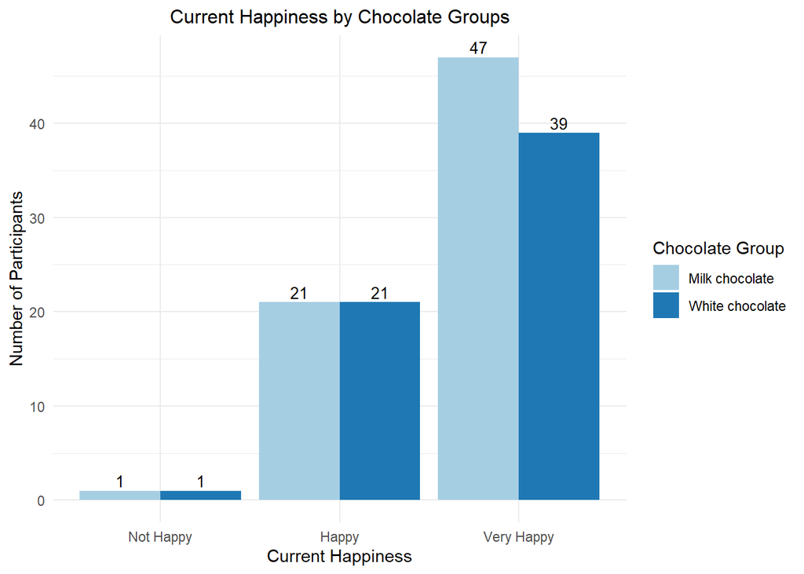

Or we could set the data up as a table:

| Chocolate Group | Not Happy | Happy | Very Happy | Total |
| --- | --- | --- | --- | --- |
| Milk chocolate | 1 | 21 | 47 | 69 |
| White chocolate | 1 | 21 | 39 | 61 |

We can also look at the data by colour group to see how many people from each group took part in the study. Do some colour groups have more people in than others? Remember colour groups were decided by age (adult/child), chocolate preference (milk/white chocolate) and happiness before eating chocolate (not happy/happy/very happy). The biggest group was the pink group, these were children who were happy before eating chocolate and preferred milk chocolate.

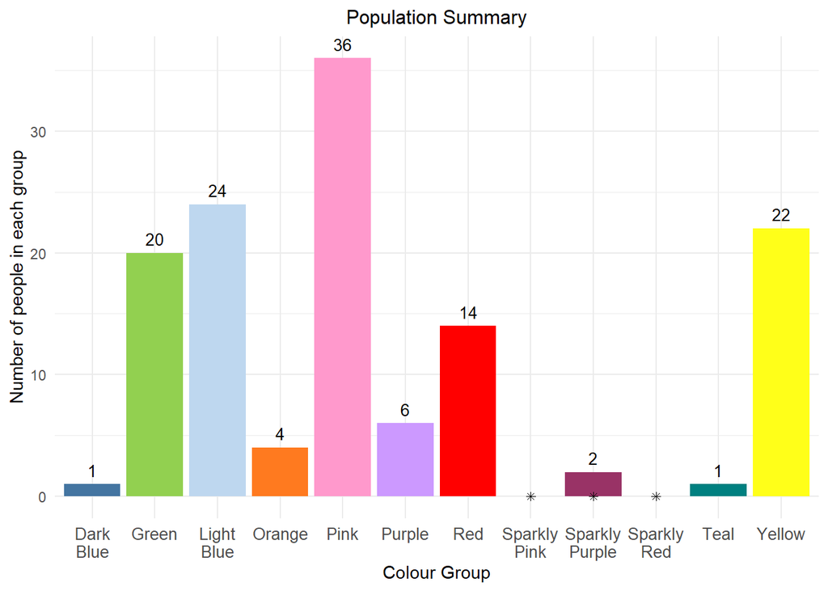

### Statistical test (suitable for 11-16 years old)

While the graphs give us an early idea about the information we’ve collected, the best way to find out if there’s a difference in happiness between the two chocolate groups is to use a statistical test. This will to help us decide if there might be a link (sometimes called an association) between chocolate group and happiness. From the people we asked at Be Curious, the results were…

```
## [1] "Fishers Test: Happiness and Chocolate Group are independent"
```

This means that there is not enough evidence to say that one chocolate group makes people happier than another. How did this compare to your thoughts from looking at the bar charts?

The issue from this test is that if we found the chocolate groups not to be independent, we wouldn’t know which group makes people happier than the other, all we would know is that there is a difference. We may also want to know whether there is a difference in peoples’ answers based on their age, happiness before eating chocolate or their chocolate preferences.

### Statistical model (suitable for 16+ years)

We can find out the answers to all of these questions too! To do this, we will use a statistical model which will produce odds ratios from which we can make our conclusions. Odds ratios show us how much more likely someone in one group (e.g. chocolate group, age group, happiness at the start of the activity) is to be happy after eating their chocolate compared to another group.

If there is no difference in happiness between the two chocolate groups then the odds ratio will be 1, we would interpret this result as ‘the type of chocolate you have does not affect your happiness.’ If the odds ratio is greater than 1, this means a person is more likely to be happy in the milk chocolate group than in the white chocolate group. If the odds ratio is lower than 1 then a person is less likely to be happy in the milk chocolate group than in the white chocolate group. When making our conclusion, it is important we also take into account the 95% confidence interval of the odds ratio, that is the range of values that we are 95% confident the odds ratio sits between. We need the confidence interval because we haven’t asked everyone our question so we only know what the result might be rather than what it definitely is.

Here our odds ratio is:

```
## [1] "0.661  ( 0.247 ,  1.765 )"
```

In addition to this, We can also see the effect that age, happiness at the start of the activity and liking milk or white chocolate has on the outcome. Putting these into a table, we can see the following:

[output not shown]

As we can see, 1 is within all confidence intervals and therefore none of the variables we recorded at baseline are deemed to have a significant effect on happiness after eating chocolate. While it may not seem as interesting, science is often about being able to rule out associations as well as prove them.  
DISCLAIMER: This does not constitute a real clinical trial and thus the results should not be taken to make any true claim on chocolate preference.

[figure not shown]